**Assignment**

**Coronavirus report of Malaysia**

**STA 326 2.0 Programming and Data Analysis with R**

**…………………………………………………………………………………………**

**AS2017412**

**P.B.Kodithuwakku**

**…………………………………………………………………………………………**

# 01.Introduction

## 1.1 Visualisationof the Location

Malaysia is a country in Southeast Asia.Malaysia is a milti-ethnic, multi-religious union of 13 states and three fedaral territories consisting of two areas devided by some 640 miles of the South China Sea. Most muslim ethnic Malay are politically dominant and benefit from positive discrimination in industry, education and civil service. but significant Chinese ethnic minority retains economyic influence. Despite ethnic and religious differences, communities are relatively united. Malaysia is a federal constitutional elective monarchy.

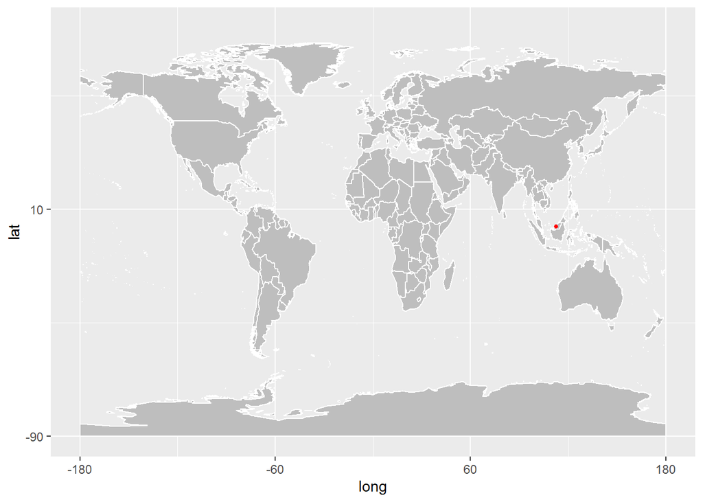

[figure not shown]

Map of Malaysia

**Area : 330,830 square kilometres**

**Capital : Kuala Lumpur**

**Population : 32,730,000**

**population Density : 92 per square kilometres**

**Prime minister : Abdullah al-haj**

## 1.2 Climate condition of Malaysia

Both peninsular and insular Malaysia lie in the same tropical latitudes and are affected by similar airsreams. Malaysia has high temperatures and humidities, heavy rainfall and a climatic year patterned around the northeast and southwest monsoons.the four seasons of the climate year are the northeast monsoon(from november or december until march), the first intermonsoonal period(from march to April or May), the southwest monsoon(from May or June to September or Octomber) and the second intermonsoonal period(Octomber to November). In this Corona Situation, they spend the first intermonsoonal period and the southwest monsoonal period. Further Malaysia has an equatorial climate and climate impacts are penetraring internally.Temperatures are uniformly high throughout the year.On the peninsula, they average about 80 Fahrenheit(27 Celsius) in most Lowland areas.Temperatures are lower in the interior highland regions. In coastal areas, minimum temperatures range from the low to mid 70 Fahrenheit(27 Celsius),and maximum temperatures hover around 90 Fahrenheit(32 Celsius). The mean annual rainfall on the Malaysia is approximately 100 inches(2,540 mm).

## 1.3 Coronavirus disease in Malaysia

Corona virus disease, a novel pneumonia disease originating in wuhan, was confirmed by the World Health Organization on 12 january 2020 before becoming an outbreak in all countries. On 25 January 2020, Malaysia reported its first three incidents, all of whom were Chinese nationals who had visited the country. Through January 30th the number of cases had risen to eight. Malaysians were also not well prepared to combat the pandemic, primarily because of the ongoing political crisis and also because they were told that the virus would not easily spread in Malaysia. However in a few weeks, Malaysia had reported the highest total number of confirmed coronavirus infections in Southeast Asia, by the end of March 2020 breaking the 2,000 active cases mark. Consequently, The government took a several measures to ease the mass panic and to protect the health of Malaysian people. The goverment of Malaysia imposed a Movment Control Order Starting on 18 march 2020 to separate the coronavirus chain. In addition, on 1 March 2020 an alliance was formed with 38 professional medical societies to support the MoH in the field of healthcare. This coalition’s intention was to keep the community well informed, and to ensure that the information provided was true and accurate.

# 02 Exploratory Data Analysis

## 2.1 Confirmed cases in the Malaysia

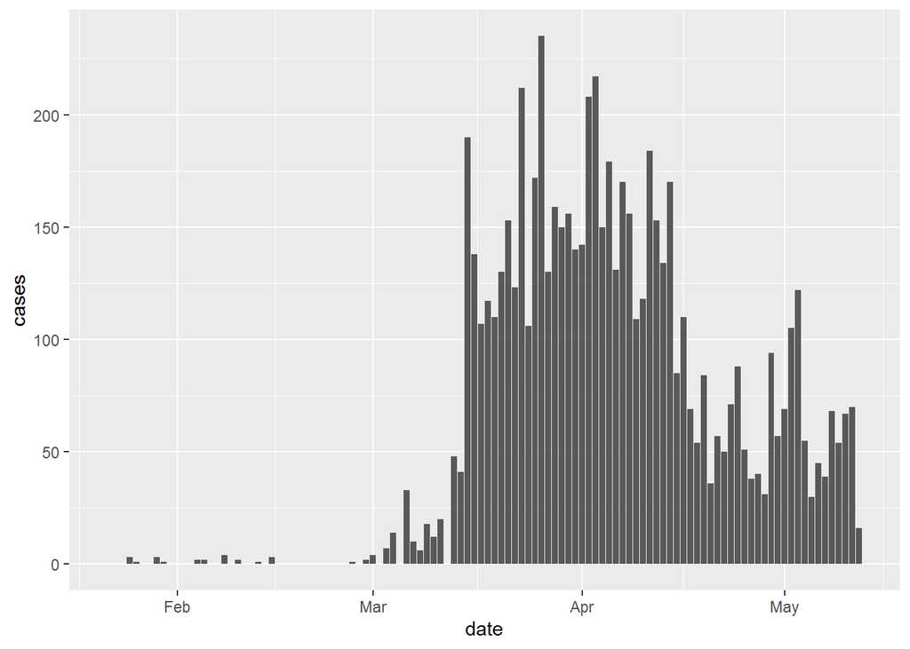

Figure 2.1: Daily covid-19 confirmed cases in Malaysia

# 2.2 Recovered cases in the Malaysia

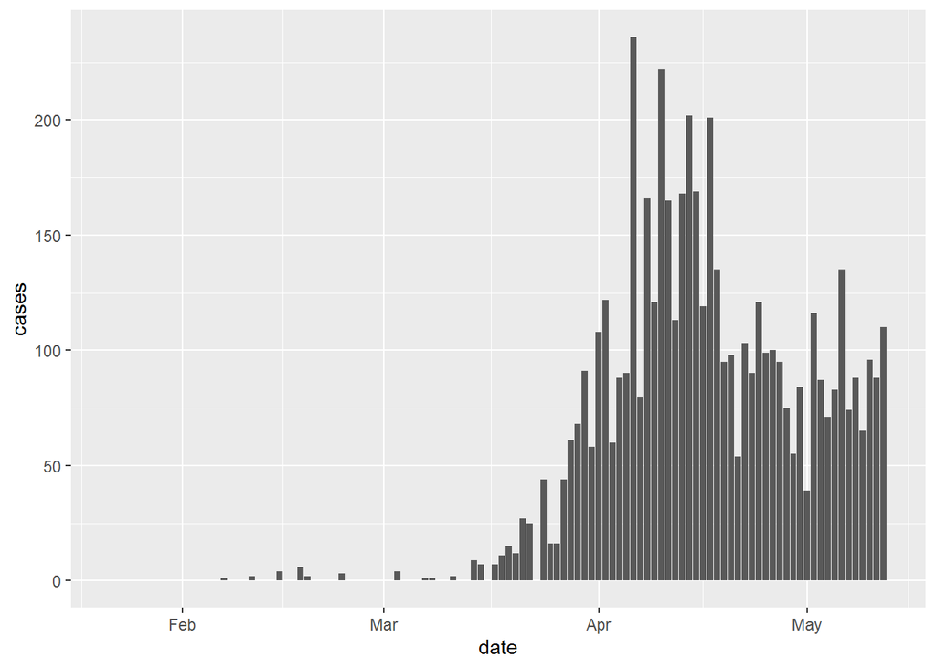

Figure 2.2: Daily covid-19 recovered cases in Malaysia

Figure 2.2 shows daily recovered covid-19 cases in Malaysia. The 1st recoverd cases of the corona virus disease in Malaysia is reported in February. Since mid-march, there has been a significant increase in the recovered cases of corona virus. The highest number of recovered ceses have reported on April.

# 2.3 Death cases in the Malaysia

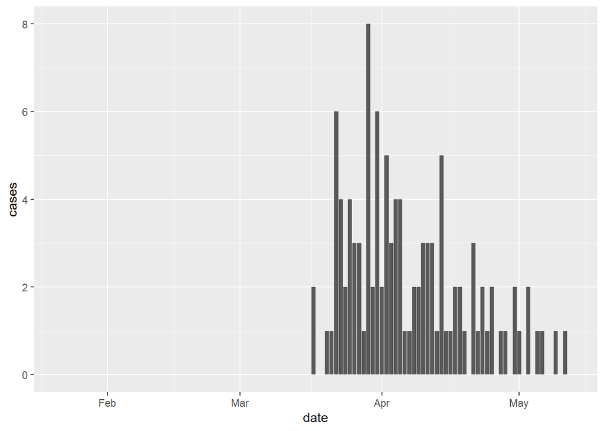

Figure 2.3: Daily covid-19 death cases in Malaysia

# 2.4 Summary cases in the Malaysia

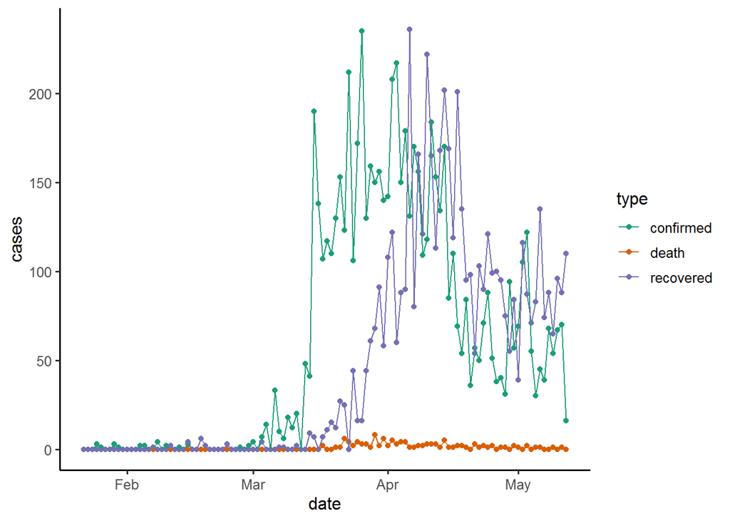

Figure 2.4: Daily covid-19 confirmed, recovered and death cases in Malaysia

Table 2.1: Summary table for covid 19 cases in Malaysia

| Country | Confirmed | Death | Recovered | Active |
| --- | --- | --- | --- | --- |
| Malaysia | 6742 | 109 | 5223 | 1410 |

Figure 2.4 shows all daily covid-19 cases in Malaysia.From March month to beginning of april month, There has been a significant increase in the confirmed cases greater than recovered cases. Since mid-april, there has been a significant increase in the recovered cases greater than confirmed cases. The number of Death cases is Significantly lower than the number of Confirmed cases. According to table 2.1 Malaysia has a 1410 active cases of covid-19

## 2.5 Comparison with Neighbouring countries

- Singapore
- Indonesia
- Thailand
- Philippines

**Confirmed cases Comparison**

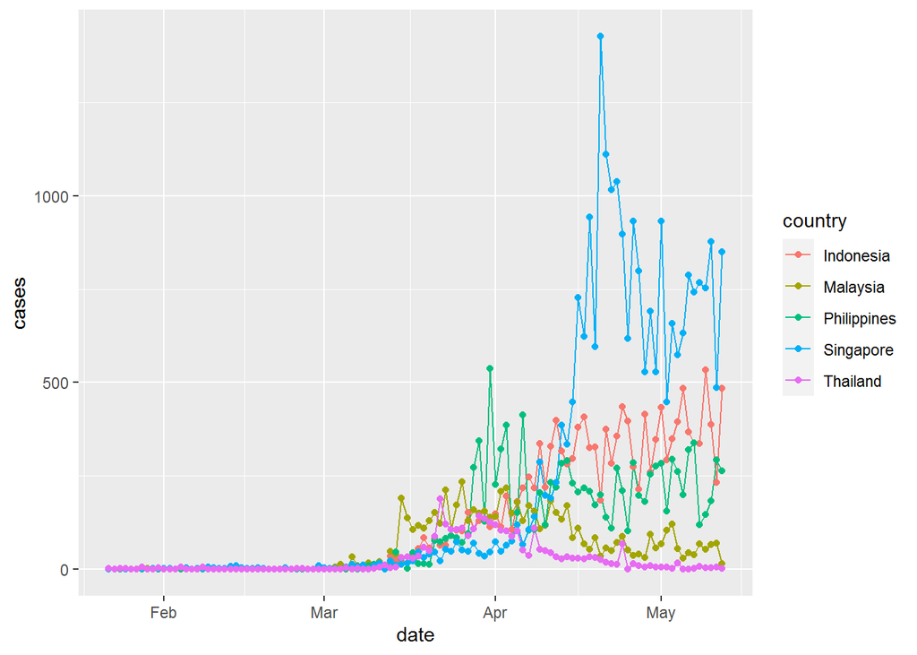

Figure 2.5.1: Daily Comfirmed cases

Acording to the Figure 2.5.1, Malaysia has a slight decrease in the spread of corona virus compared to Singapore, Indonesia and Philippines.because of that Singapore, Indonesia and Philippines covid-19 confirmed cases is greater than malaysia covid-19 confirmed cases. but Thailand covid-19 confirmed cases is Significantly lower than malaysia covid-19 confirmed cases.

**Recovered cases Comparison**

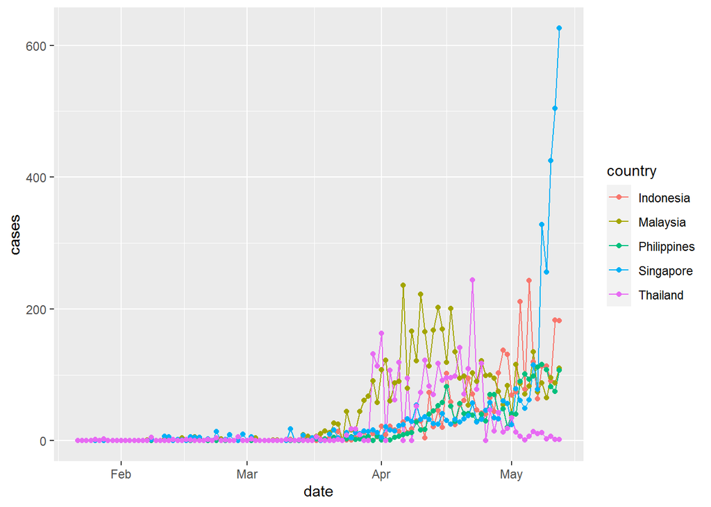

Figure 2.5.2: Daily recovered cases

**Death cases Comparison**

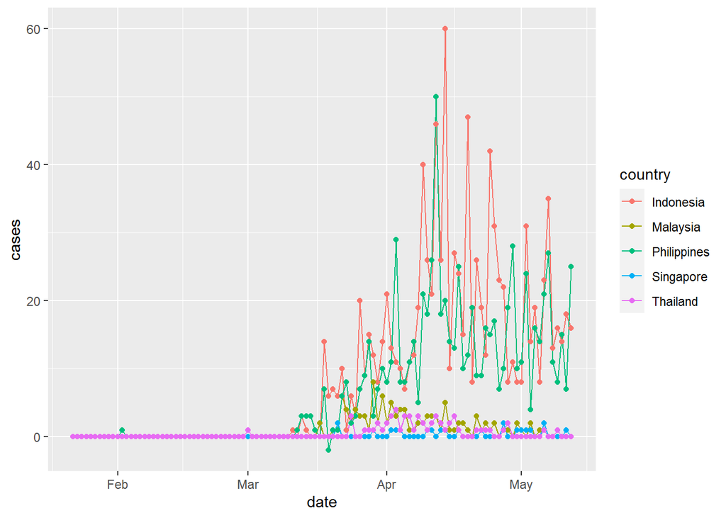

Figure 2.5.3: Daily Death cases

Figure 2.5.3 shows the daily covid 19 death cases in Malaysia, Singapore, Indonesia, Philippine and Thailand.Indonesia and Philipphine has a Significant increse in the Death cases of corona virus compared to Malaysia, Singapore and Thailand. Malaysia will be able to control theire daily deaths in this situation.

**Summary cases Comparison table**

| Country | Confirmed | Death | Recovered | Active |
| --- | --- | --- | --- | --- |
| Malaysia | 6742 | 109 | 5223 | 1410 |
| Indonesia | 14749 | 1007 | 3063 | 10679 |
| Philippines | 11350 | 751 | 2106 | 8493 |
| Singapore | 24671 | 21 | 3851 | 20799 |
| Thailand | 3017 | 56 | 2798 | 163 |

## 2.6 Comparison with USA and China

We are going to compare with USA and China. because of that China reported the first covid-19 case, and the US and China reported the largest number of covid-19 cases.but US and China are a biggest countries.further those countries are developed countries. So this part we can’t take a idea about corona disease. because the population of these countries are vastly different.However We can get a rough idea of the spread of corona virus in Malaysia with powerful countries.

**Confirmed cases Comparison**

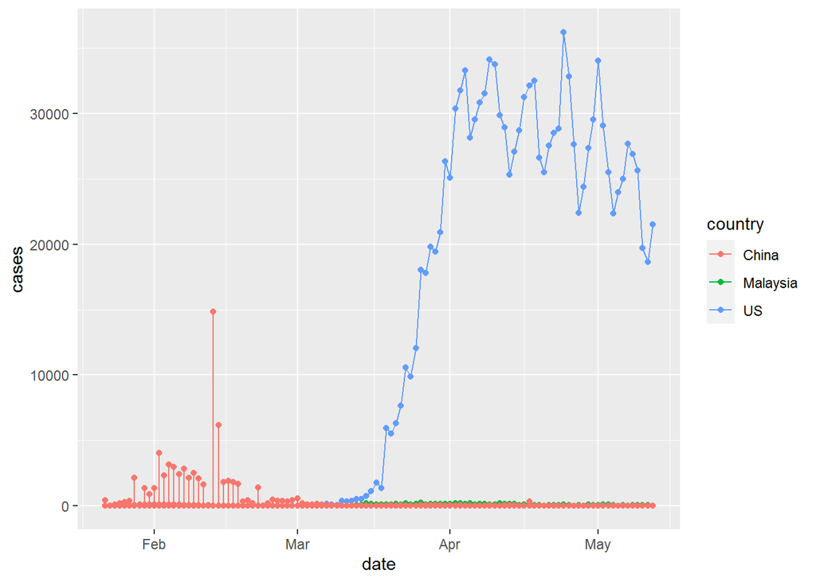

Figure 2.6.1: Daily Comfirmed cases

Figure 2.6.1 shows the daily covid 19 confirmed cases in Malaysia, China and US. According to the this figure China and US covid-19 confirmed cases is greater than malaysia covid-19 confirmed cases. However, there has been a decline in the confirmed cases of covid-19 in China since March. But There has been a huge increse in the number of Daily covid-19 confirmed cases in US compared to Malaysia and China Since mid-march. The number of daily confirmed cases in the US exceeds the 30,000 limit in April.

**Recovered cases Comparison**

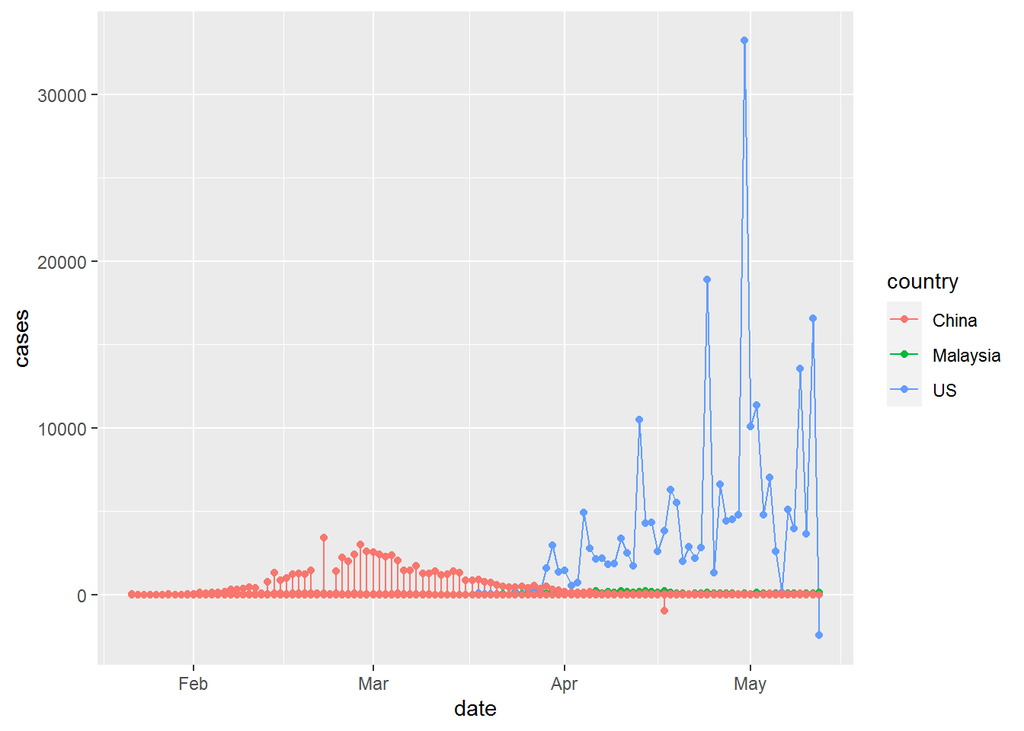

Figure 2.6.2: Daily recovered cases

**Death cases Comparison**

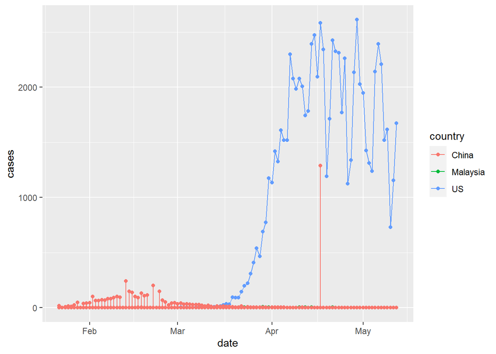

Figure 2.6.3: Daily Death cases

Figure 2.6.3 shows the daily covid 19 death cases in Malaysia, China and US. Malaysia has a significantly decrease in the death cases of corona virus compared to China and US.Since mid-March, There has been a significant increase in the death cases of corona virus in US compared to China and Malaysia. In mid-April, Unexpected corona deaths were reported in china.

**Summary cases Comparison table**

| Country | Confirmed | Death | Recovered | Active |
| --- | --- | --- | --- | --- |
| Malaysia | 6742 | 109 | 5223 | 1410 |
| US | 1369376 | 82356 | 230287 | 1056733 |
| China | 84018 | 4637 | 79222 | 159 |